# Shootings in the U.S. in 2018

Jared Reddy

02/24/2020

## Shootings in the US in 2018

In 2018, the United States had a total of 340 shootings occur with a total number of 373 lives lost. The city that was most impacted by these shootings, meaning the total number of lives lost and casualties, was Chicago. In the year of 2018, the highest number of state casualties was tied between California, Illinois.

## Summary Table

| City | Number of People Killed |
| --- | --- |
| Chicago | 27 |
| Philadelphia | 11 |
| Memphis | 9 |
| Saint Louis | 9 |
| New Orleans | 6 |
| Washington | 6 |
| Baltimore | 5 |
| Jacksonville | 5 |
| Los Angeles | 5 |
| Miami | 5 |

On February 14, 2018, a former High School student opened fire on a school in Florida killing a total of 17 and injuring an additional 17. In the [CNN](https://www.cnn.com/2018/02/14/us/florida-high-school-shooting/index.html) report that the shooting was one of the top 10 worst in U.S. history. The student, Nikolas Cruz, had been expelled from the high school for disciplinary reasons previously. The shooting shook Parkland, Florida to it’s core as it was one of the safest cities to live in in the state. The school went into lockdown as soon as gunshots had begun. Nikolas Cruz was said to have used a .223 caliber AR-15 style gun for the shooting.

## Interactive Map

[interactive chart not shown]

The interactive map above is showing all shootings that have happened in the U.S. in the year of 2018. The legend sorts color of dots by how many deaths occurred at each shooting. By viewing this map, we can see that a lot of shootings occur on the east coast with shootings on the west coast being more clustered.

## Data Plot

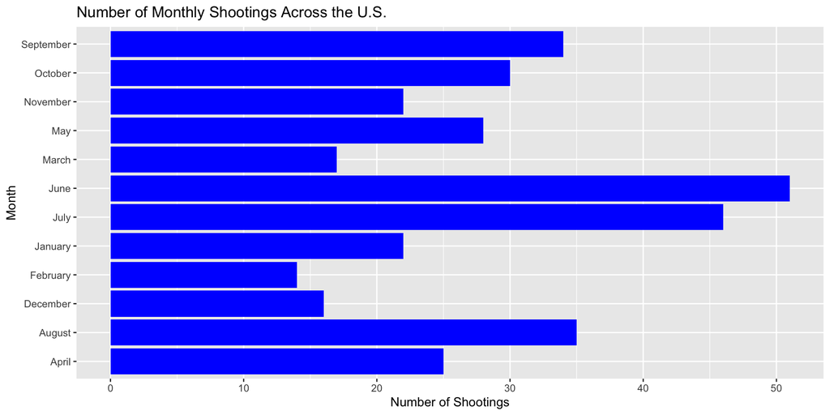

In the plot above, we can see the number of shootings along the X-Axis and the Month the shootings occurred on the Y-Axis. With the plotted data, we can see if there is any correlation between shootings and the seasons. The data shows more shootings occur in the warmer seasons versus shootings and colder seasons.